# Project: Wrangle and Analyze Data

This Udacity project aims to practice a typical data wrangling process. This includes gathering data from a variety of sources, such as CSV-files, TSV-files and an API: The Twitter-API. Then its cleanly- and tidiness will be assessed in order to correct quality issues, converting the data to a tidy dataset. This happens according to the rules of tidiness https://cran.r-project.org/web/packages/tidyr/vignettes/tidy-data.html. Once quality and tidiness is assured, the sources will be combined to one or more master datasets before finally analyzing and visualizing it.

Note: Assessing and wrangling the entirety of the dataset would require more time than provided by Udacity. They, therefore, required to find at least eight quality and two tidiness issues to be assessed and cleaned. Keep in mind, there may be more issues still present.

- Gathering Data
- Assessing Data
- Cleaning Data
- Storing Cleaned Data
- Joining Data For Analysis
- Analysis
- Gathering
- References

## Gathering Data

```python
#Importing libraries
import pandas as pd
import numpy as np
import requests
import json
import tweepy
import time
import matplotlib.pyplot as plt
import seaborn as sns
from IPython.display import Image
```

#### Twitter Archive

```python
df_twitter_archive = pd.read_csv('input_raw_data/twitter-archive-enhanced.csv')
```

```python
df_twitter_archive.sample(3)
```

|  | tweet_id | in_reply_to_status_id | in_reply_to_user_id | timestamp | source | text | retweeted_status_id | retweeted_status_user_id | retweeted_status_timestamp | expanded_urls | rating_numerator | rating_denominator | name | doggo | floofer | pupper | puppo |
| --- | --- | --- | --- | --- | --- | --- | --- | --- | --- | --- | --- | --- | --- | --- | --- | --- | --- |
| 607 | 798209839306514432 | NaN | NaN | 2016-11-14 17:03:50 +0000 | <a href="http://twitter.com/download/iphone" r... | This is Cooper. His bow tie was too heavy for ... | NaN | NaN | NaN | https://twitter.com/dog_rates/status/798209839... | 13 | 10 | Cooper | None | None | None | None |
| 788 | 774314403806253056 | NaN | NaN | 2016-09-09 18:31:54 +0000 | <a href="http://twitter.com/download/iphone" r... | I WAS SENT THE ACTUAL DOG IN THE PROFILE PIC B... | NaN | NaN | NaN | https://twitter.com/dog_rates/status/774314403... | 14 | 10 | None | None | None | None | None |
| 1646 | 683834909291606017 | NaN | NaN | 2016-01-04 02:18:42 +0000 | <a href="http://twitter.com/download/iphone" r... | Here we see a faulty pupper. Might need to rep... | NaN | NaN | NaN | https://twitter.com/dog_rates/status/683834909... | 9 | 10 | None | None | None | pupper | None |

#### Image Predictions

```python
downloaded_response = requests.get("https://d17h27t6h515a5.cloudfront.net/topher/2017/August/599fd2ad_image-predictions/image-predictions.tsv")
with open('input_raw_data/image-predictions.tsv', 'wb') as file:
    file.write(downloaded_response.content)

# Putting contents of the downloaded file into a data frame, using the read_csv-function.
# A tsv-file differs only by the separator from a csv-file.
    df_image_predictions = pd.read_csv('input_raw_data/image-predictions.tsv', sep='\t')
```

```python
df_image_predictions.head()
```

|  | tweet_id | jpg_url | img_num | p1 | p1_conf | p1_dog | p2 | p2_conf | p2_dog | p3 | p3_conf | p3_dog |
| --- | --- | --- | --- | --- | --- | --- | --- | --- | --- | --- | --- | --- |
| 0 | 666020888022790149 | https://pbs.twimg.com/media/CT4udn0WwAA0aMy.jpg | 1 | Welsh_springer_spaniel | 0.465074 | True | collie | 0.156665 | True | Shetland_sheepdog | 0.061428 | True |
| 1 | 666029285002620928 | https://pbs.twimg.com/media/CT42GRgUYAA5iDo.jpg | 1 | redbone | 0.506826 | True | miniature_pinscher | 0.074192 | True | Rhodesian_ridgeback | 0.072010 | True |
| 2 | 666033412701032449 | https://pbs.twimg.com/media/CT4521TWwAEvMyu.jpg | 1 | German_shepherd | 0.596461 | True | malinois | 0.138584 | True | bloodhound | 0.116197 | True |
| 3 | 666044226329800704 | https://pbs.twimg.com/media/CT5Dr8HUEAA-lEu.jpg | 1 | Rhodesian_ridgeback | 0.408143 | True | redbone | 0.360687 | True | miniature_pinscher | 0.222752 | True |
| 4 | 666049248165822465 | https://pbs.twimg.com/media/CT5IQmsXIAAKY4A.jpg | 1 | miniature_pinscher | 0.560311 | True | Rottweiler | 0.243682 | True | Doberman | 0.154629 | True |

#### Twitter-API: Retrieving Additional Post Data

```python
#Authentication
consumer_key = ""
consumer_secret = ""
access_token = ""
access_secret = ""

auth = tweepy.OAuthHandler(consumer_key, consumer_secret)
auth.set_access_token(access_token, access_secret)

api = tweepy.API(auth, wait_on_rate_limit=True, wait_on_rate_limit_notify=True)
#including handling parameters for timeouts
```

```python
# Testing functionality
test = api.get_status(892420643555336193, wait_on_rate_limit=True, wait_on_rate_limit_notify=True)
test != "" # Check
```

```python
# Copying the tweet ids of the archvie to a list, iterating through it
tweet_ids = []
tweet_ids = df_twitter_archive.tweet_id.copy()

# Creating a list, to put to the tweets in (as JSON-objects)
tweets_json_lake = []
```

```python
# Measuring elapsed time for retrieving information from the Twitter API.
start_time_twitter_api = time.time()

# Iterating through all tweet ids to retrieve the entire post as an object.
for tweet_id in tweet_ids:
    # Using the try-and-except method to handle non-existing tweet_ids: Cases where no information can be obtained.
    try:
        # Using the get_status function of tweepy to retrieve the post, including the retweeted and favorite counts.
        tweet_status = api.get_status(tweet_id, wait_on_rate_limit=True, wait_on_rate_limit_notify=True)
        # Appending the tweet (as a json-object to the list of tweets)
        tweets_json_lake.append(tweet_status._json)
        # Empyting variable for the next iteration
        tweet_status = ""
        #print(str(tweet_id)) #Can be used to monitor
    except:
        print("Retrieving information of tweet ID " + str(tweet_id) + " failed.")
```

```python
# Creating or opening the file tweets_json.text in write mode, to put the list of tweets into.
with open ('input_raw_data/tweet_json.txt', 'w') as outfile:
    json.dump(tweets_json_lake, outfile)

print("Tweet information stored to file.")
#Stop timing
end_time_twitter_api = time.time()
print("Elapsed time for retrieving tweet information: " + str(end_time_twitter_api - start_time_twitter_api) + "seconds.")
```

Please note: The last five cells were executed only once, in order to retrieve the information from the Twitter API. Once the information was retrieved I did not run those cells anymore, hence the missing output. This due to the fact that running the concern tweet ids throught the API takes 20-30 minutes each time.

```python
# Loading JSON-file into a list
with open ('input_raw_data/tweet_json.txt') as json_file:
    tweet_json = json.load(json_file)

# Converting the list to pandas data frame
df_tweet_performance = pd.DataFrame(tweet_json)
```

```python
df_tweet_performance.sample(3)
```

|  | contributors | coordinates | created_at | entities | extended_entities | favorite_count | favorited | geo | id | id_str | ... | quoted_status | quoted_status_id | quoted_status_id_str | retweet_count | retweeted | retweeted_status | source | text | truncated | user |
| --- | --- | --- | --- | --- | --- | --- | --- | --- | --- | --- | --- | --- | --- | --- | --- | --- | --- | --- | --- | --- | --- |
| 2329 | None | None | Mon Nov 16 01:22:45 +0000 2015 | {'hashtags': [], 'symbols': [], 'user_mentions... | {'media': [{'id': 666063820255862784, 'id_str'... | 465 | False | None | 666063827256086533 | 666063827256086533 | ... | NaN | NaN | NaN | 213 | False | NaN | <a href="http://twitter.com/download/iphone" r... | This is the happiest dog you will ever see. Ve... | False | {'id': 4196983835, 'id_str': '4196983835', 'na... |
| 2261 | None | None | Thu Nov 19 20:20:22 +0000 2015 | {'hashtags': [], 'symbols': [], 'user_mentions... | {'media': [{'id': 667437270979485701, 'id_str'... | 450 | False | None | 667437278097252352 | 667437278097252352 | ... | NaN | NaN | NaN | 242 | False | NaN | <a href="http://twitter.com/download/iphone" r... | Never seen this breed before. Very pointy pup.... | False | {'id': 4196983835, 'id_str': '4196983835', 'na... |
| 941 | None | None | Sat Jul 09 01:08:47 +0000 2016 | {'hashtags': [], 'symbols': [], 'user_mentions... | {'media': [{'id': 751583840003584000, 'id_str'... | 4638 | False | None | 751583847268179968 | 751583847268179968 | ... | NaN | NaN | NaN | 1196 | False | NaN | <a href="http://twitter.com/download/iphone" r... | Please stop sending it pictures that don't eve... | False | {'id': 4196983835, 'id_str': '4196983835', 'na... |

3 rows × 30 columns

```python
# Dropping all un-needed columns from to data frame, by converting the JSON again, needed columns only.
# Needed columns: (tweet)ID, retweet_count, favorite_count
df_tweet_performance = pd.DataFrame(tweet_json, columns=["id", "retweet_count", "favorite_count"])

# Renaming column id to tweet_id for merging later on.
df_tweet_performance.rename(columns = {'id':'tweet_id'}, inplace=True)

df_tweet_performance.sample(3)
```

|  | tweet_id | retweet_count | favorite_count |
| --- | --- | --- | --- |
| 881 | 759159934323924993 | 1256 | 0 |
| 1171 | 718540630683709445 | 1074 | 2586 |
| 2310 | 666411507551481857 | 323 | 438 |

```python
# It may occur, that when the python notebook ran twice or more times, without first deleting the tweet_json.txt file,
# that duplicates will be created as the API calls are simply appended to the file.
# The easiest way is to deduplicate the data frame before continuing the analysis.

# It may also occur, that the python notebook ran at different days, meanwhile the performance of a tweet
# has increased (i.e. has higher retweet or favorite count). Hence, the row as a whole would not be a duplicate anymore.
# Checking if there are any duplicate tweet_ids are existent.

print("Duplicates before cleaning: "+ str(sum(df_tweet_performance.tweet_id.duplicated())))
df_tweet_performance.drop_duplicates(subset="tweet_id", inplace=True)
print("Duplicates after cleaning: "+ str(sum(df_tweet_performance.tweet_id.duplicated())))
```

```
Duplicates before cleaning: 0
Duplicates after cleaning: 0
```

## Assessing Data

In this section the data sources are going to be assessed one by one. The first part of each data source outlines the process of assessing and shows my approach. The second part states observations and issues I have found be fixed. Please note: general observations cannot be categorized as issues. However, these are points which need to be adressed prior to the analysis as a kind of "General Preparation".

### Table 1: Twitter Archive

```python
# Checking the overall table structure, data types and for missing values.
# Missing values in serveral columns. The interpretation of data types are plausible.
df_twitter_archive.info()
```

```
<class 'pandas.core.frame.DataFrame'>
RangeIndex: 2356 entries, 0 to 2355
Data columns (total 17 columns):
tweet_id                      2356 non-null int64
in_reply_to_status_id         78 non-null float64
in_reply_to_user_id           78 non-null float64
timestamp                     2356 non-null object
source                        2356 non-null object
text                          2356 non-null object
retweeted_status_id           181 non-null float64
retweeted_status_user_id      181 non-null float64
retweeted_status_timestamp    181 non-null object
expanded_urls                 2297 non-null object
rating_numerator              2356 non-null int64
rating_denominator            2356 non-null int64
name                          2356 non-null object
doggo                         2356 non-null object
floofer                       2356 non-null object
pupper                        2356 non-null object
puppo                         2356 non-null object
dtypes: float64(4), int64(3), object(10)
memory usage: 313.0+ KB
```

There are missing values in several columns. The missing values in the columns starting with "in*reply..." and "retweeted*" are of no further interest. The instructions state only "original Tweets" shall be part of the analysis. Furthermore there values missing in the column "expanded_urls".

```python
# Deep dive into the column expanded URLs to identify the shortcomings in detail.
df_twitter_archive.expanded_urls.value_counts()
```

```
https://twitter.com/dog_rates/status/740373189193256964/photo/1,https://twitter.com/dog_rates/status/740373189193256964/photo/1,https://twitter.com/dog_rates/status/740373189193256964/photo/1,https://twitter.com/dog_rates/status/740373189193256964/photo/1                                             …
https://twitter.com/dog_rates/status/782305867769217024/photo/1,https://twitter.com/dog_rates/status/782305867769217024/photo/1,https://twitter.com/dog_rates/status/782305867769217024/photo/1                                                                                                             …
https://twitter.com/dog_rates/status/698195409219559425/photo/1                                                                                                                                                                                                                                             …
https://twitter.com/dog_rates/status/759923798737051648/photo/1                                                                                                                                                                                                                                             …
https://twitter.com/dog_rates/status/762464539388485633/photo/1,https://twitter.com/dog_rates/status/762464539388485633/photo/1,https://twitter.com/dog_rates/status/762464539388485633/photo/1,https://twitter.com/dog_rates/status/762464539388485633/photo/1                                             …
https://twitter.com/dog_rates/status/681523177663676416/photo/1                                                                                                                                                                                                                                             …
https://twitter.com/dog_rates/status/704761120771465216/photo/1,https://twitter.com/dog_rates/status/704761120771465216/photo/1                                                                                                                                                                             …
https://twitter.com/dog_rates/status/775733305207554048/photo/1                                                                                                                                                                                                                                             …
https://www.gofundme.com/lolas-life-saving-surgery-funds,https://twitter.com/dog_rates/status/835264098648616962/photo/1,https://twitter.com/dog_rates/status/835264098648616962/photo/1                                                                                                                    …
https://www.loveyourmelon.com/pages/ourstory,https://twitter.com/dog_rates/status/820314633777061888/photo/1,https://twitter.com/dog_rates/status/820314633777061888/photo/1,https://twitter.com/dog_rates/status/820314633777061888/photo/1                                                                …
https://twitter.com/dog_rates/status/759447681597108224/photo/1                                                                                                                                                                                                                                             …
https://twitter.com/dog_rates/status/786709082849828864/photo/1                                                                                                                                                                                                                                             …
https://twitter.com/dog_rates/status/673295268553605120/photo/1                                                                                                                                                                                                                                             …
https://twitter.com/dog_rates/status/817827839487737858/video/1                                                                                                                                                                                                                                             …
https://twitter.com/dog_rates/status/739238157791694849/video/1                                                                                                                                                                                                                                             …
https://twitter.com/dog_rates/status/809220051211603969/photo/1,https://twitter.com/dog_rates/status/809220051211603969/photo/1                                                                                                                                                                             …
https://twitter.com/dog_rates/status/761672994376806400/video/1                                                                                                                                                                                                                                             …
https://twitter.com/dog_rates/status/771380798096281600/photo/1,https://twitter.com/dog_rates/status/771380798096281600/photo/1,https://twitter.com/dog_rates/status/771380798096281600/photo/1,https://twitter.com/dog_rates/status/771380798096281600/photo/1                                             …
```

[output cut: 44 more lines]

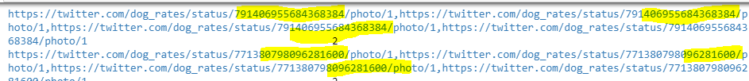

```python
 Image("images/urls_1.PNG")
```

The screenshot above shows duplicates withtin one single cell, i.e. the url is stated more than one time per row. The redundant information can be extracted.

```python
# Checking for duplicated rows across all columns.
sum(df_twitter_archive.duplicated())
```

```
0
```

```python
# Checking for duplicates across the index-colum tweet ID. Since this column will serve as an element to join values from
# other tables, there should no duplicated values be present.
sum(df_twitter_archive.tweet_id.duplicated())
```

```
0
```

```python
# Checking other relevant columns for duplicated content.
print(sum(df_twitter_archive.text.duplicated()))
print(sum(df_twitter_archive.expanded_urls.duplicated()))
```

```
0
137
```

```python
# Generating output to sample visually. How does the issue exactly look like?
duplicated_rows_twitter_archive_url = df_twitter_archive["expanded_urls"].duplicated(keep=False) # keeps both entries
df_duplicated_tw_archive_url = df_twitter_archive[duplicated_rows_twitter_archive_url]
df_duplicated_tw_archive_url.sort_values("expanded_urls", inplace = True)
df_duplicated_tw_archive_url.to_csv("temp_output/duplicated_expanded_urls.csv")

# Visual assessment revealed that many duplicated image URLs are present in rows with retweets. However, I encountered
# at least one real duplicate which means, cleaning duplicates will make sense anyway.
```

[figure not shown]

```python
 Image("images/urls_2.PNG")
```

The screenshot above shows the following:

- Green: duplicate expanded_urls originating from a "retweet" row. Does not matter,Will be cleaned anyway.
- Yellow: a real duplicate entry. This issue must be fixed.

```python
# Checking the value consistency among each column. Although this approach can be much of scrolling, for this rather short dataset
#it is very effective value assessing.

for column in df_twitter_archive:
    print(df_twitter_archive[column].value_counts())
    print('\n')
```

[output not shown]

[output cut: 608 more lines]

```


None       2346
floofer      10
Name: floofer, dtype: int64


None      2099
pupper     257
Name: pupper, dtype: int64


None     2326
puppo      30
Name: puppo, dtype: int64
```

```python
# Detailed check values of column rating_numerator, since many values appear to be odd.
# Filtering outlying values.
df_numerator_check = df_twitter_archive[(df_twitter_archive.rating_numerator > 20) | (df_twitter_archive.rating_numerator < 1)]

# Checking how many rows are outlying.
df_numerator_check.info()
# 26 rows have rare numerator values.
# Exporting them to CSV in order to check the details in a spreadsheet application.
df_numerator_check.to_csv('temp_output/numerator_check.csv')
# Conclusion: outlying values are either just typos, incorrect extracted or due to exaggeration. Since the amount is quite low I decide to delete
#these rows to increase the reliability of the analysis while keeping time efforts at a minimum.
```

```
<class 'pandas.core.frame.DataFrame'>
Int64Index: 26 entries, 188 to 2074
Data columns (total 17 columns):
tweet_id                      26 non-null int64
in_reply_to_status_id         6 non-null float64
in_reply_to_user_id           6 non-null float64
timestamp                     26 non-null object
source                        26 non-null object
text                          26 non-null object
retweeted_status_id           1 non-null float64
retweeted_status_user_id      1 non-null float64
retweeted_status_timestamp    1 non-null object
expanded_urls                 22 non-null object
rating_numerator              26 non-null int64
rating_denominator            26 non-null int64
name                          26 non-null object
doggo                         26 non-null object
floofer                       26 non-null object
pupper                        26 non-null object
puppo                         26 non-null object
dtypes: float64(4), int64(3), object(10)
memory usage: 3.7+ KB
```

```python
# Detailed check values of column rating_denominator, since some values appear to be odd.
# Filtering outlying values.
df_denominator_check = df_twitter_archive[(df_twitter_archive.rating_denominator > 10) | (df_twitter_archive.rating_denominator < 10)]

# Checking how many rows are outlying.
df_denominator_check.info()
# 23 rows have rare denominator values.
# Exporting them to CSV in order to check the details in a spreadsheet application.
df_denominator_check.to_csv('temp_output/denominator_check.csv')
# Conclusion: outlying values are either just typos, incorrect extracted or due to exaggeration. Since the amount is quite low I decide to delete
#these rows to increase the reliability of the analysis while keeping time efforts at a minimum.
```

```
<class 'pandas.core.frame.DataFrame'>
Int64Index: 23 entries, 313 to 2335
Data columns (total 17 columns):
tweet_id                      23 non-null int64
in_reply_to_status_id         5 non-null float64
in_reply_to_user_id           5 non-null float64
timestamp                     23 non-null object
source                        23 non-null object
text                          23 non-null object
retweeted_status_id           1 non-null float64
retweeted_status_user_id      1 non-null float64
retweeted_status_timestamp    1 non-null object
expanded_urls                 19 non-null object
rating_numerator              23 non-null int64
rating_denominator            23 non-null int64
name                          23 non-null object
doggo                         23 non-null object
floofer                       23 non-null object
pupper                        23 non-null object
puppo                         23 non-null object
dtypes: float64(4), int64(3), object(10)
memory usage: 3.2+ KB
```

```python
# Detailed check of the columns source. The above analysis implied, there might be odd values.
df_twitter_archive.source.value_counts()
```

```
<a href="http://twitter.com/download/iphone" rel="nofollow">Twitter for iPhone</a>     2221
<a href="http://vine.co" rel="nofollow">Vine - Make a Scene</a>                          91
<a href="http://twitter.com" rel="nofollow">Twitter Web Client</a>                       33
<a href="https://about.twitter.com/products/tweetdeck" rel="nofollow">TweetDeck</a>      11
Name: source, dtype: int64
```

```python
# There are no values present, the source might be an Android app.
# It could have been, that the users may have used mostly the iOS app for posting.
# the "<a href ...>" code parts do not add any value.
# Conclusion: it does not matter too much. This columns appears to not add value from the analytics perspective.
# The column shall be dropped.
```

The observations and issues to this dataset as listed below. This serves as a summary.

#### General Observations

The following points cannot be categorized as issues. These point are of a general nature and need to be adressed and handled prior to the analysis. The handling is described in the section "General Preparations" in the "Cleaning Data" section.

1. According to the instructions tweets beyond August 1st, 2017 shall not be included in the analysis as no prediction of the breed (by image) is available for that period. The concerning post data shall be deleted from the twitter_archive dataset.
2. Missing values in columns in_reply_to_status_id, in_reply_to_user_id. Since these values are optional values they can be ignored. Furthermore, both columns have the same amount of values. This implies consistency, as the columns relate to each other.
3. Missing values in columns retweeted_status_id, retweeted_status_user_id, retweeted_status_timestamp. Since these values are optional values they can be ignored. Furthermore, both columns have the same amount of values. This implies consistency, as the columns relate to each other.
4. According to the instructions retweets and replies will not be part of the analysis. Rows with values can be dropped. Then the empty columns can be dropped as well.
5. The fact that rating numerators are (mostly) greater than the denominators does not need to be cleaned according to the project's instructions. This is seen as part of the unique rating system of WeRateDogs.

#### Tidiness Issues

**Optional, in case analysis would be extended to replies and retweets:**

1. The column set of "in_reply_to_status_id, in_reply_to_user_id" and "retweeted_status_id, retweeted_status_user_id, retweeted_status_timestamp" form different sets of observational units are can therefore be separated from the rest of the data by storing each set into a new table. The column tweet_id can be used as a 1 to 1 or identifier.

**Optional if analysis would need to cover the special classifications "doggo, floofer, pupper, puppo"**

2. The columns doggo, floofer, pupper, puppo are untidy as the values are stored in column names. These can be combined to one column stating the "special classification". For the purpose of this analysis, these columns shall be dropped.

Note to the reviewer: I left it integer because this type consumes less storage capacity and this there faster in handling.

### Table 2: Image Predictions

The following section describes the process of assessing this data set. The issues are stated thereafter.

```python
# Checking the overall structure visually by 30 randomly drawn rows.
df_image_predictions.sample(30)
```

|  | tweet_id | jpg_url | img_num | p1 | p1_conf | p1_dog | p2 | p2_conf | p2_dog | p3 | p3_conf | p3_dog |
| --- | --- | --- | --- | --- | --- | --- | --- | --- | --- | --- | --- | --- |
| 946 | 704499785726889984 | https://pbs.twimg.com/media/Ccbi0UGWoAA4fwg.jpg | 1 | Chihuahua | 0.376541 | True | Siamese_cat | 0.098057 | False | Labrador_retriever | 0.085211 | True |
| 1605 | 800443802682937345 | https://pbs.twimg.com/media/CsVO7ljW8AAckRD.jpg | 1 | mousetrap | 0.777468 | False | black_widow | 0.093940 | False | paddlewheel | 0.017492 | False |
| 684 | 683852578183077888 | https://pbs.twimg.com/media/CX2ISqSWYAAEtCF.jpg | 1 | toy_poodle | 0.551352 | True | teddy | 0.180678 | False | miniature_poodle | 0.164095 | True |
| 1168 | 735991953473572864 | https://pbs.twimg.com/media/CjbExRKUoAAs089.jpg | 2 | cocker_spaniel | 0.961643 | True | toy_poodle | 0.011547 | True | soft-coated_wheaten_terrier | 0.004903 | True |
| 805 | 691756958957883396 | https://pbs.twimg.com/media/CZmdSD8UcAAnY5R.jpg | 1 | Saint_Bernard | 0.342571 | True | boxer | 0.289096 | True | Pembroke | 0.076463 | True |
| 574 | 678446151570427904 | https://pbs.twimg.com/media/CWpTLOYWsAEDhcU.jpg | 1 | Staffordshire_bullterrier | 0.284492 | True | Rottweiler | 0.189434 | True | American_Staffordshire_terrier | 0.189430 | True |
| 1215 | 743510151680958465 | https://pbs.twimg.com/ext_tw_video_thumb/74350... | 1 | sea_lion | 0.859046 | False | tub | 0.020405 | False | hippopotamus | 0.013095 | False |
| 1073 | 716802964044845056 | https://pbs.twimg.com/media/CfKYfeBXIAAopp2.jpg | 2 | malinois | 0.619577 | True | Leonberg | 0.118089 | True | bull_mastiff | 0.066508 | True |
| 19 | 666273097616637952 | https://pbs.twimg.com/media/CT8T1mtUwAA3aqm.jpg | 1 | Italian_greyhound | 0.176053 | True | toy_terrier | 0.111884 | True | basenji | 0.111152 | True |
| 1159 | 733828123016450049 | https://pbs.twimg.com/media/Ci8UxxcW0AYgHDh.jpg | 2 | beagle | 0.472324 | True | Walker_hound | 0.121779 | True | Saint_Bernard | 0.114640 | True |
| 1354 | 760252756032651264 | https://pbs.twimg.com/media/Coz12OLWgAADdys.jpg | 1 | radio_telescope | 0.155279 | False | dam | 0.154515 | False | crane | 0.098040 | False |
| 1709 | 818145370475810820 | https://pbs.twimg.com/media/C1qi26rW8AMaj9K.jpg | 1 | golden_retriever | 0.621931 | True | Labrador_retriever | 0.364997 | True | redbone | 0.003971 | True |
| 553 | 677573743309385728 | https://pbs.twimg.com/media/CWc5uVPXIAErLYr.jpg | 2 | patio | 0.535070 | False | folding_chair | 0.080419 | False | parallel_bars | 0.034796 | False |
| 1592 | 798673117451325440 | https://pbs.twimg.com/media/CV_cnjHWUAADc-c.jpg | 1 | dough | 0.806757 | False | bakery | 0.027907 | False | French_loaf | 0.018189 | False |
| 1739 | 822462944365645825 | https://pbs.twimg.com/media/C2n5rUUXEAIXAtv.jpg | 3 | Pomeranian | 0.960199 | True | Samoyed | 0.023056 | True | Maltese_dog | 0.008945 | True |
| 212 | 670037189829525505 | https://pbs.twimg.com/media/CUxzQ-nWIAAgJUm.jpg | 1 | pot | 0.273767 | False | tray | 0.092888 | False | doormat | 0.050728 | False |
| 450 | 674739953134403584 | https://pbs.twimg.com/media/CV0oaHFW4AA9Coi.jpg | 1 | Dandie_Dinmont | 0.175915 | True | black-footed_ferret | 0.096534 | False | toy_poodle | 0.064145 | True |
| 1847 | 839290600511926273 | https://pbs.twimg.com/media/C6XBt9XXEAEEW9U.jpg | 1 | web_site | 0.670892 | False | monitor | 0.101565 | False | screen | 0.075306 | False |
| 1797 | 831552930092285952 | https://pbs.twimg.com/media/C4pE-I0WQAABveu.jpg | 1 | Chihuahua | 0.257415 | True | Pembroke | 0.161442 | True | French_bulldog | 0.092143 | True |
| 1587 | 798209839306514432 | https://pbs.twimg.com/media/CxPPnCYWIAAo_ao.jpg | 1 | Pekinese | 0.524583 | True | Shih-Tzu | 0.102931 | True | Pomeranian | 0.097893 | True |
| 1650 | 809220051211603969 | https://pbs.twimg.com/media/CzrtWDbWEAAmIhy.jpg | 1 | Pomeranian | 0.819511 | True | Samoyed | 0.141241 | True | Pembroke | 0.013455 | True |
| 1468 | 778990705243029504 | https://pbs.twimg.com/media/Cs-H5uhWcAAiNY9.jpg | 2 | cocker_spaniel | 0.715351 | True | Labrador_retriever | 0.207056 | True | Chihuahua | 0.028519 | True |
| 323 | 671874878652489728 | https://pbs.twimg.com/media/CVL6op1WEAAUFE7.jpg | 1 | china_cabinet | 0.996031 | False | entertainment_center | 0.001986 | False | bookcase | 0.001652 | False |
| 956 | 705428427625635840 | https://pbs.twimg.com/media/CcovaMUXIAApFDl.jpg | 1 | Chihuahua | 0.774792 | True | quilt | 0.073079 | False | Pembroke | 0.022365 | True |
| 1612 | 801538201127157760 | https://pbs.twimg.com/media/Cx-itFWWIAAZu7l.jpg | 1 | Pembroke | 0.550506 | True | Cardigan | 0.306612 | True | Shetland_sheepdog | 0.054230 | True |
| 1394 | 767500508068192258 | https://pbs.twimg.com/media/Cqa1ofnXEAAG0yn.jpg | 1 | chow | 0.483228 | True | golden_retriever | 0.165063 | True | Norfolk_terrier | 0.060173 | True |
| 1880 | 846874817362120707 | https://pbs.twimg.com/media/C8C0JYHW0AAy-7u.jpg | 2 | Shetland_sheepdog | 0.450539 | True | papillon | 0.187928 | True | collie | 0.140068 | True |
| 167 | 668986018524233728 | https://pbs.twimg.com/media/CUi3PIrWoAAPvPT.jpg | 1 | doormat | 0.976103 | False | Chihuahua | 0.005640 | True | Norfolk_terrier | 0.003913 | True |
| 1253 | 748307329658011649 | https://pbs.twimg.com/media/CmKFi-FXEAAeI37.jpg | 2 | paddle | 0.589066 | False | shovel | 0.038062 | False | mountain_tent | 0.029203 | False |
| 1562 | 793500921481273345 | https://pbs.twimg.com/media/CwMU34YWIAAz1nU.jpg | 2 | golden_retriever | 0.326122 | True | Labrador_retriever | 0.219904 | True | Chesapeake_Bay_retriever | 0.163366 | True |

```python
df_image_predictions.info()
# This table looks good at first glance. No missing values, data types are all correctly interpreted, hence no sign for
#invalid values.
# However, the predication values are partly stored within the column names and is therefore an issue of tidyness.
```

```
<class 'pandas.core.frame.DataFrame'>
RangeIndex: 2075 entries, 0 to 2074
Data columns (total 12 columns):
tweet_id    2075 non-null int64
jpg_url     2075 non-null object
img_num     2075 non-null int64
p1          2075 non-null object
p1_conf     2075 non-null float64
p1_dog      2075 non-null bool
p2          2075 non-null object
p2_conf     2075 non-null float64
p2_dog      2075 non-null bool
p3          2075 non-null object
p3_conf     2075 non-null float64
p3_dog      2075 non-null bool
dtypes: bool(3), float64(3), int64(2), object(4)
memory usage: 152.1+ KB
```

```python
# Checking for duplicated rows across all columns.
sum(df_image_predictions.duplicated())
```

```
0
```

```python
# Checking for duplicates across the index-column tweet ID. Since this column will serve as an element to join values from
#other tables, there should ideally no duplicated values be present.
sum(df_image_predictions.tweet_id.duplicated())
```

```
0
```

```python
# Checking other relevant columns for duplicated content.
print(sum(df_image_predictions.jpg_url.duplicated()))
```

```
66
```

```python
duplicated_rows_image_predictions_jpg_url = df_image_predictions["jpg_url"].duplicated(keep=False) # keeps both entries
df_duplicated_image_predictions_jpg_url = df_image_predictions[duplicated_rows_image_predictions_jpg_url]
df_duplicated_image_predictions_jpg_url.sort_values("jpg_url", inplace = True)
df_duplicated_image_predictions_jpg_url.to_csv("temp_output/duplicated_image_urls_image_predictions.csv")
```

```python
# Programmatic assessment revealed there are 66 duplicates entries present, however, each pair has a different tweet id.
# The visual (see screenshot below) assessment lets me assume each pair has identical image prediction values. If that is the case, the duplicates do not need
# to be deleted. That way, chances are higher that an image prediction is available for each tweet id from the
# twitter archive dataset.
```